# Homework 3-2

Author

Affiliation

Nicholas Adu Gyamfi

Old Dominion University

This homework focuses on a relatively hot topic in the United States: marijuana legalization. In 1996, California became the first state to legalize medical marijuana. Between then and 2010, 14 other states legalized medical marijuana. Since then, states have begun legalizing recreational marijuana, but that’s a topic for another day. One of the arguments against legalizing marijuana is that marijuana and alcohol are complements (which is testable) and traffic safety will reduce by way of increased intoxicated driving (which is also testable). In their 2013 *Journal of Law and Economics* paper titled [Medical Marijuana Laws, Traffic Fatalities, and Alcohol Consumption](https://doi.org/10.1086/668812), Anderson, Hansen, and Rees examine these hypotheses in a difference-in-differences framework. You should read through this paper before completing the Homework.[^1]

### Question 1

Summarize the main research question in the paper, the setting analyzed, and why DiD is appropriate for this research question. (**2 Points**)

The DiD methodology is appropriate for evaluating the causal influence of policy changes. DiD allows the authors to compare outcomes (changes in traffic fatalities) before and after the legalization of medical marijuana in treated states with changes in control states over time whilst controlling for confounding factors. This enables authors to isolate the causal effect of the legislation on traffic fatalities and alcohol consumption.

### Question 2

Describe the data analyzed, including general structure of the data set, sources, and the nature of the data.

1. First, read in the [fatalities data](https://alexcardazzi.github.io/econ708/data/fars_state-year.csv) and call it `fars`. (**1 point**)

```r
fars <- read.csv("https://alexcardazzi.github.io/econ400/data/fars_state-year.csv")

# Change column Name
colnames(fars)[colnames(fars) == 'state.code'] <- 'code'
```

2. Replicate the mean and standard deviation of the total fatality rate in Table 4. *Note*: these are weighted summary statistics. (**1 point**)

```r
library(modelsummary)

# Fatalities per 100,000 people
fat_per_100k <- data.frame((fars$deaths/fars$population) * 100000)

# summary statistics
datasummary_skim(fat_per_100k, fmt = "%.3f", title = "Mean and Standard Deviation of the Total Fatality Rate in Table 4")
```

Mean and Standard Deviation of the Total Fatality Rate in Table 4

|  | Unique | Missing Pct. | Mean | SD | Min | Median | Max |  |
| --- | --- | --- | --- | --- | --- | --- | --- | --- |
| X.fars.deaths.fars.population....1e.05 | 1071 | 0 | 16.268 | 5.991 | 3.989 | 15.565 | 38.432 |  |

3. Use Table 1 in [Anderson *et al.* (2013)](https://doi.org/10.1086/668812) to help you create a variable to denote the treatment status for each state in each year.[^2] (**1 point**)

```r
state_yr_ref <- data.frame(state = c("Alaska","California","Colorado","District of Columbia","Hawaii","Maine","Michigan","Montana","Nevada","New Jersey","New Mexico","Oregon","Rhode Island","Vermont","Washington"),
                        year =c(1999,1997,2002,2011,2001,2000,2009,2005,2002,2011,2008,1999,2006,2005,1999))

## Match and add treatment year to the states
fars$MML <- state_yr_ref$year[match(fars$state, state_yr_ref$state)]
```

4. Finally, create a variable that measures the time since the MML was passed for each state. Think carefully about how to denote states that are never treated. (**1 point**)

```r
## Measure relative time since MML was passed for each Treatment state,
## For all controls states input -1
fars$rel_year <- ifelse(is.na(fars$MML), -1, fars$year - fars$MML)


## Evaluate DiD
#fars$DiD <- ifelse(fars$rel_year >= 0, 1, 0)
fars$post <- ifelse(fars$rel_year >= 0, 1, 0)


## Filter treatment states(1) and control states(0)
fars$treat_state <- ifelse(fars$state %in% state_yr_ref$state, 1, 0)
```

### Question 3

Discuss the general assumptions underlying the causal inference method used in the empirical analysis.

1. How do the authors address these assumptions in the paper (if at all)? (**1 point**)

To ensure the validity of their results, the authors tackle key assumptions underlying causal inference in their analysis as follows.

First, they address the assumption of parallel trends by incorporating state and year fixed effects, state-specific linear time trends, and a set of control variables, such as economic conditions and policies, into their regression models. Additionally, they conducted rigorous verification tests, including regression analyses with placebo medical marijuana laws assigned to control states, to bolster their findings.

Second, to address the Stable Unit Treatment Value Assumption (SUTVA), the authors employ a number of controls, state and year fixed effects, and state-specific linear time-trends to mitigate the impact of time-invariant unobservable factors at the state level.

Third, the authors addressed the anticipation assumption by investigating the relationship between policy variables and the enactment of medical marijuana laws. Their analysis reveals limited evidence that alcohol or drug-related policies predicted the legalization of medical marijuana.

Lastly, the authors dealt with the issues of endogeneity by conducting diagnostic tests, including regressions with placebo medical marijuana laws assigned to control states. With these tests, the authors addressed biases to ensure the robustness of their results.

Overall, by employing a robust empirical strategy, incorporating a diverse set of controls, and conducting various tests, the authors effectively addressed key assumptions in causal inference, enhancing the credibility and validity of their findings.

2. Include a discussion of threats to validity of the results in terms of causal inference. (**1 point**)

The study faces some potential threats to the causal interpretation of its results. First, a primary concern is the assumption that legalization (MML) is related to traffic fatalities exclusively through alcohol. Given that the first-stage F-statistic of the null hypothesis that legalization is unrelated to alcohol is less than 10, this raises some concerns about interpretation of the second-stage estimate. Thus, it is possible the empirical strategy’s assumption may not fully capture the complex relationship between medical marijuana legalization and traffic fatalities.

Second is endogeneity, the authors addressed this issue by running a series of regressions in which a placebo MML was randomly assigned to each control state. While the estimated coefficient of the placebo medical marijuana laws was generally negative and statistically significant only 10 times out of 300 trials, there may still be unobserved variables or omitted variable bias that could impact the results.

Third, The anticipation assumption suggests that consumers could have adjusted their behavior in anticipation of legalization (MML). The authors employed a rich set of controls to address the possibility that legalization went hand in hand with other behaviors or policies related to traffic fatalities.

3. Since this empirical setting examines a staggered rollout, what do you think about the authors empirical strategy? (**1 point**)

For a staggered rollout of medical marijuana legalization across states, the empirical strategy should aim at evaluating the impact of legalization on various outcomes while accounting for the staggered timing of policy implementation. Here are some of the authors empirical strategy and my analysis of its;

First, the authors identify states that have legislated MML (treatment) at different time intervals and those that have not (control) as an empirical strategy. To minimize confounding factors, the authors must ensure the treatment and control groups are comparable. Of the 51 states in the US, only 15 had legislated (MML) and as such considered as treatment for the study. This could be problematic as the treatment group is far less than the control group.

Second, since empirical setting examines a staggered rollout, there is the need to model the treatment effect by allowing differential timing of policy across states as well as incorporate time indicators to capture the effects of policy changes at different times. The authors controlled for time-invariant unobservable factors at the state level. Additionally, the authors incorporate state and year fixed effects, state-specific linear time trends, and controls, such as economic conditions and policies, in their regression analyses.

Third, there is the need to utilize datasets from reliable sources, such as government surveys, administrative records, or publicly available databases. The authors collated datasets from the fatality analysis reporting system (FARS) database, Behavioral Risk Factor Surveillance System (BRFSS) and High Times magazines among others. However, the authors reliance on High Times magazine may introduce some uncertainty, this is because the authors acknowledge that NSDUH is the best source of information on marijuana consumption. however this data does not provide individual-level data with state identifiers to researchers and did not publish state-level estimates of marijuana use prior to 1999.

### Question 4

Create a figure similar in spirit to Figures 1-3 in the paper. Instead of breaking down the fatality rate by age group as the authors do, just use the total fatality rate supplied in the data. *Note*: these are also weighted numbers. This is difficult, and you have to read the paper carefully. (**2 points**)

```r
set.seed(123)

### Create aunique states where treat_state = 0 and MML is NA
unique_states <- unique(fars$state[fars$treat_state == 0 & is.na(fars$MML)])

### Create years sequence from 1996 to 2010
years <- 1996:2010

# Shuffle the sequence of years with replacement
shuffle_yrs <- sample(years, length(unique_states), replace = TRUE)

# Create Vector to map each state to its corresponding year
state_year_map <- setNames(shuffle_yrs, unique_states)

# Assign the shuffled years to NA in MML column for each state
fars$MML2 <- NA

fars$MML2[fars$treat_state == 0 & is.na(fars$MML)] <- state_year_map[fars$state[fars$treat_state == 0 & is.na(fars$MML)]]

# Assign non-NA values from MML column to MML2 column
fars$MML2 <- ifelse(!is.na(fars$MML), fars$MML, fars$MML2)

## For all controls states input -1
fars$rel_year2 <- fars$year - fars$MML2


agg <- aggregate((fars$deaths/fars$population)*100000, list(fars$rel_year2, fars$treat_state), mean)
#print(agg)

# Plot of DiD Curves
plot(agg$Group.1, agg$x,
     las = 1, type = "n",
     main = "Impact of MML",
     #ylim = c(),
     #xlim = c(-5, 5),
     ylab = "Average Fatality Rate", xlab = "Year")

lines(agg$Group.1[agg$Group.2 == 0],
      agg$x[agg$Group.2 == 0],
      col = "black", lty = 2)

lines(agg$Group.1[agg$Group.2 == 1],
      agg$x[agg$Group.2 == 1],
      col = "blue")
```

**Plot**

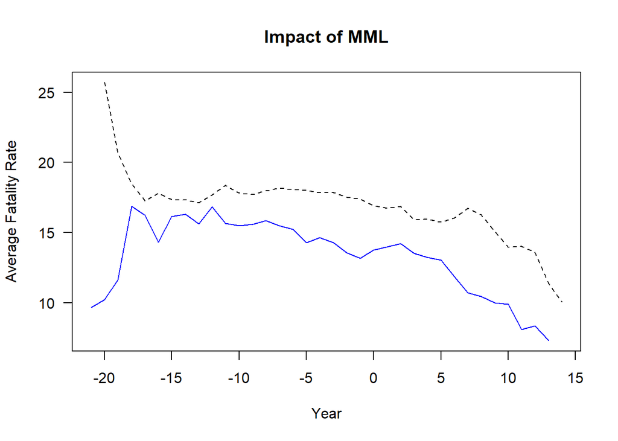

### Question 5

Run a Goodman-Bacon decomposition.[^3] Interpret the output. (**2 points**)

```r
library("bacondecomp")

fars$deaths_log <- log(fars$deaths)

bacondecomp::bacon(deaths_log ~ post,
                    data = fars,
                    id_var = "state",
                    time_var = "year",
                    quietly = F) -> fars_decomp
```

**Output**

```
                      type  weight  avg_est
1 Earlier vs Later Treated 0.06595 -0.00211
2 Later vs Earlier Treated 0.03311  0.01677
3     Treated vs Untreated 0.90093 -0.04831
```

Results from the Goodman-Bacon function, enables us to interpret the decomposed DiD (TWFE) by its component parts. It allows us to estimate the contribution and weights of each 2x2 component. This output summarizes the three possible comparisons: Early vs late Treated, Treated vs Untreated and Late vs Early Treated. The average estimate shows that whilst Earlier vs Treated and Treated vs Untreated have negative average estimates, Later vs Earlier Treated has a positive average estimate. Visual inspection of the graph and and intuition shows a negative trend. Thus this result shows the cause of the anomaly, regression of the Later on the Earlier Treated. We use various techniques to correct this such as the Gardner (Two-stage DiD) or the stacked DiD approach.

### Question 6

Replicate the main result reported in the paper.

1. Recreate columns (1) and (2) of Table 6. Note that this is a simple TWFE result. Be sure to include all the bells and whistles[^4] sans their controls. Present the coefficient estimates in a `modelsummary` table. (**1 point**)

```r
## State Specific Linear Time Trends
## Without State-specific linear time trends
r_es1 <- fixest::feols(deaths_log ~ post | state + year, data = fars, weights = ~population)
#summary(r_es1)

## With State-specific linear time trends (SSLTT)
r_es2 <- fixest::feols(deaths_log ~ post + state:year | state + year, data = fars, weights = ~population)
#summary(r_es2)

regz <- list(`TWFE without State-specific linear time trends` = r_es1,
             `TWFE with State-specific linear time trends` = r_es2)

## Use modelsummary to output the results
coefz <- c("post" = "Difference in Difference",
           "state" = "State Fixed Effect",
           "year" = "Year Fixed Effect",
           "state:year" = "Interaction",
           "(Intercept)" = "Constant")

gofz <- c("nobs", "r.squared")

modelsummary(regz,
             title = "Medical Marijuana Laws and Total Traffic Fatalities, 1990–2010",
             estimate = "{estimate}{stars}",
             coef_map = coefz,
             gof_map = gofz)
```

Medical Marijuana Laws and Total Traffic Fatalities, 1990–2010

|  | TWFE without State-specific linear time trends | TWFE with State-specific linear time trends |
| --- | --- | --- |
| Difference in Difference | −0.091** | −0.076+ |
|  | (0.032) | (0.039) |
| Num.Obs. | 1071 | 1071 |
| R2 | 0.991 | 0.995 |

2. Use the two stage difference-in-differences method in Gardner (2021)[^5] to re-estimate columns (1) and (2). (**1 point**)

```r
## State-specific linear time trends (SSLTT)

library("did2s")

es_did2_1 <- did2s(fars, yname = "deaths_log",
                  first_stage = ~ 0 | state + year,
                  second_stage = ~ post,
                  treatment = "post",
                  cluster_var = "state")

es_did2_2 <- did2s(fars, yname = "deaths_log",
                  first_stage = ~ 0 | state + year,
                  second_stage = ~ post + i(state,year),
                  treatment = "post",
                  cluster_var = "state")

## Use modelsummary to output the results
regz <- list(`Two-Stage DiD without State-specific linear time trends` = es_did2_1,
             `Two-Stage DiD with State-specific linear time trends` = es_did2_2)

coefz <- c("post" = "Difference in Difference",
           "state" = "State Fixed Effect",
           "year" = "Year Fixed Effect",
           "state:year" = "Interaction",
           "(Intercept)" = "Constant")

gofz <- c("nobs", "r.squared")

modelsummary(regz,
             title = "Medical Marijuana Laws and Total Traffic Fatalities, 1990–2010",
             estimate = "{estimate}{stars}",
             coef_map = coefz,
             gof_map = gofz)
```

Medical Marijuana Laws and Total Traffic Fatalities, 1990–2010

|  | Two-Stage DiD without State-specific linear time trends | Two-Stage DiD with State-specific linear time trends |
| --- | --- | --- |
| Difference in Difference | −0.057+ | −0.044 |
|  | (0.031) | (0.032) |
| Num.Obs. | 1071 | 1071 |
| R2 | 0.029 | 0.074 |

3. Estimate event study versions of columns (1) and (2). When plotting, use `xlim = c(-10, 10)`. (**1 point**)

```r
## Without State-specific linear time trends
r_es1 <- fixest::feols(deaths_log ~ post + i(rel_year2, ref = -c(1, Inf))| state + year, data = fars, weights = ~population)
#summary(r_es1)

fixest::iplot(r_es1, xlim = c(-10, 10))


## With State-specific linear time trends (SSLTT)
r_es2 <- fixest::feols(deaths_log ~ post + i(rel_year2, ref = -c(1, Inf)) + state:year | state + year, data = fars, weights = ~population)

fixest::iplot(r_es2, xlim = c(-10, 10))
```

**Plot**

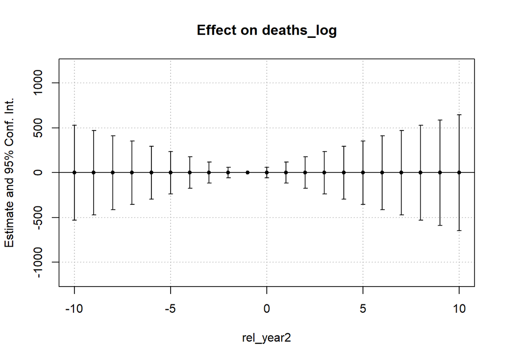

**Plot**

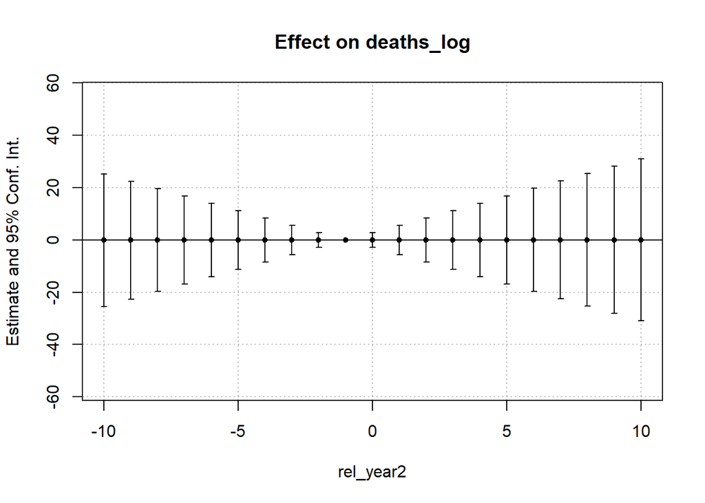

4. Estimate event study versions of columns (1) and (2) using Gardner (2021). When plotting, use `xlim = c(-10, 10)`. (**1 point**)

```r
## State Specific Linear Time Trend (SSLTT)
## Event Study using Gardner
es_did2_1a <- did2s(fars, yname = "deaths_log",
                  first_stage = ~ 0 | state + year,
                  second_stage = ~ post + i(rel_year2, ref = -c(1, Inf)),
                  treatment = "post",
                  cluster_var = "state")

es_did2_1a |>
  fixest::iplot(
    main     = "Two-Stage DiD (Without SSLTT)",
    xlab     = "Time to treatment",
    drop     = "[[:digit:]]{2}",    # Drop any leads/lags greater than |9|
    ref.line = 1
  )


## Event Study using Gardner
es_did2_2a <- did2s(fars, yname = "deaths_log",
                  first_stage = ~ 0 | state + year,
                  second_stage = ~ post  + year + i(rel_year2, ref = -c(1, Inf)),
                  treatment = "post",
                  cluster_var = "state")

es_did2_2a |>
  fixest::iplot(
    main     = "Two-Stage DiD (With SSLTT)",
    xlab     = "Time to treatment",
    drop     = "[[:digit:]]{2}",    # Drop any leads/lags greater than |9|
    ref.line = 1
  )
```

**Plot**

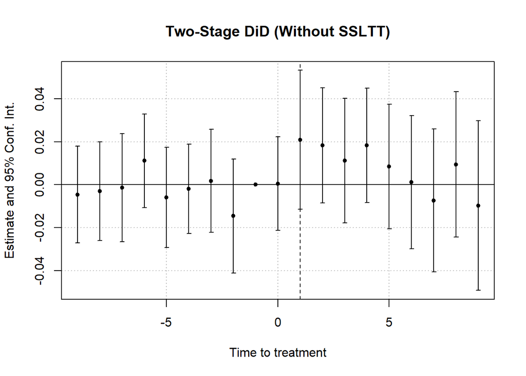

**Plot**

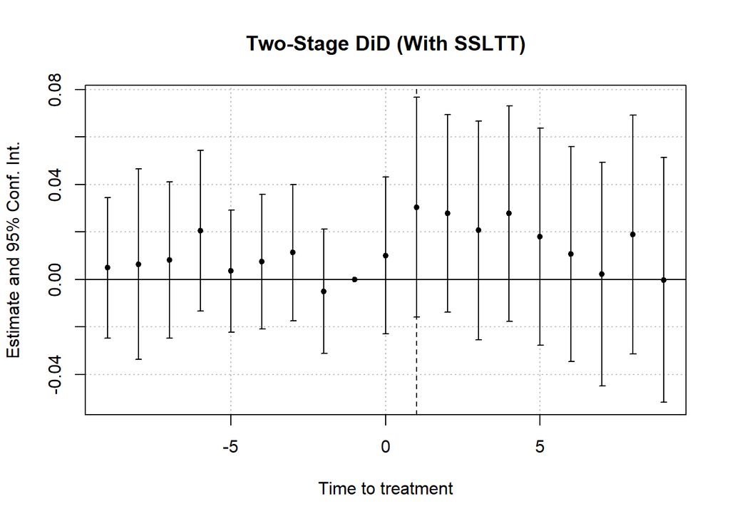

5. Using Gardner (2021) and the specification in columns (1) and (2), examine the effect of MMLs on the log of per-capita VMT. (**1 point**)

```r
r_es5 <- fixest::feols(log(vmt/population) ~ post | state + year, data = fars, weights = ~population)
summary(r_es5)
```

**Output**

```
OLS estimation, Dep. Var.: log(vmt/population)
Observations: 1,071
Weights: population
Fixed-effects: state: 51,  year: 21
Standard-errors: Clustered (state)
      Estimate Std. Error  t value   Pr(>|t|)
post -0.057066    0.01311 -4.35277 6.6429e-05 ***
---
Signif. codes:  0 '***' 0.001 '**' 0.01 '*' 0.05 '.' 0.1 ' ' 1
RMSE: 74.3     Adj. R2: 0.959627
             Within R2: 0.11416
```

### Question 7

Discuss the results generated. What is the interpretation of the causal parameter of interest? Place the causal effect in the context of the setting.

1. Compare the TWFE and 2SDiD results for fatalities. What do you think about the results in Anderson *et al.* (2013)? (**1 point**)

These models estimate the effect of MML on percentage of recorded deaths, after controlling for state-specific linear time trends, state fixed effects, year fixed effects, and adjusting for differences in population size across states. Results from the model shows the DiD coefficient of both a two-way fixed effect (TWFE) and a two-stage DiD (TSDiD) model with and without State-Specific Linear Time Trends.

The two-stage DiD coefficient associated with legalization (MML) in the second stage represents the average effect across all states, after accounting for differences in characteristics and trends. Including state-specific linear time trends in the model allows for differential trends in outcomes across states over time. The state-specific linear time trends capture variations in fatalities across states over time. Without state-specific linear time trends, the model assumes the effect of legalization (MML) is constant across all states over time.

Not only this, but legalization also led to a negative (-0.044) and insignificant effect even when SSLTT was accounted for in the model. Thus, although a negative estimate of legalization indicates a decrease in the vehicular fatalities associated with the introduction of MML across all states, this value is statistically insignificant.

The estimated TWFE seems to be consistent in sign, with the findings in Anderson *et al.* (2013). In this study they found a negative and significant estimate (-0.110) when SSLTT was not accounted for and a negative and insignificant estimate (-0.098) after accounting for SSLTT. This informed their conclusion that legalization leads to a 10.4 percent decrease in the fatality rate.

2. Discuss the results for per-capita VMT. (**1 point**)

The estimated coefficient from this evaluation is (-0.057066). This suggests a decrease in the average percentage change in vehicle miles traveled per population after passage of the MML across all states and years. This results is interesting, there might be other factors not being account for that might be causing this result.

### Question 8

Do you believe the results are credibly causal? Are the signs and magnitudes plausible? Why or why not? (**1 points**)

The results of the study appear credible for several reasons. First, the study employs a rigorous empirical methodology, utilizing the Difference-in-Differences (DiD) approach while controlling for factors at the state level as well as potential shocks. Not only is the choice of method appropriate for this study, but it also improves the credibility of the results. The authors address potential biases by conducting diagnostics tests such as placebo tests.

Secondly, the study utilizes data from reliable sources such as the Centers for Disease Control and Prevention’s Web-Based Injury Statistics Query and Reporting System (WISQARS) and the Behavioral Risk Factor Surveillance System (BRFSS). The inclusion of state and year fixed effects, along with state-specific time trends in the regression, further strengthens the credibility of the findings.

Furthermore, the results of their detailed study are corroborated by my model, which is not as thorough. Finally, the sign of the significant estimates is consistent with my results. For these reasons I believe the results are credibly causal.

## Footnotes

[^1]: The PDF will be made available on Canvas.
[^2]: You might have to make some judgement calls about which year should be the first year of treatment. This is what makes research tricky!
[^3]: Do not print the giant output, just the small summary table version.
[^4]: See the table notes for the specifics.
[^5]: [Kyle Butts’s vignette](https://kylebutts.github.io/did2s/articles/Two-Stage-Difference-in-Differences.html); [Asjad Naqvi’s vignette](https://asjadnaqvi.github.io/DiD/docs/code_r/07_did2s_r/)